# **Project - Classification and Hypothesis Testing: Hotel Booking Cancellation Prediction**

#### **Question 6.5: What are some important features based on the tuned decision tree? (1 Mark)**

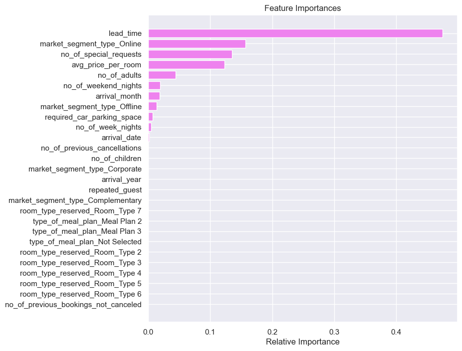

```python
# Remove _________ and complete the code

# Importance of features in the tree building

importances = estimator.feature_importances_
indices = np.argsort(importances)

plt.figure(figsize=(8, 8))
plt.title("Feature Importances")
plt.barh(range(len(indices)), importances[indices], color="violet", align="center")
plt.yticks(range(len(indices)), [feature_names[i] for i in indices])
plt.xlabel("Relative Importance")
plt.show()
```

**Write your answers here:**_**** The most important features are:

- lead_time
- market_segment_type_Online
- no_of_special_requests
- avg_price_per_room

### **Question 7: Random Forest (4 Marks)**

#### **Question 7.1: Build a Random Forest Model (1 Mark)**

```python
# Remove _________ and complete the code

rf_estimator = RandomForestClassifier(class_weight = {0: 0.67, 1: 0.33}, random_state = 1)

rf_estimator.fit(X_train, y_train)
```

```
RandomForestClassifier(class_weight={0: 0.67, 1: 0.33}, random_state=1)
```

#### **Question 7.2: Check the performance of the model on the train and test data (2 Marks)**

```
              precision    recall  f1-score   support

           0       0.99      1.00      1.00     17073
           1       1.00      0.98      0.99      8319

    accuracy                           0.99     25392
   macro avg       1.00      0.99      0.99     25392
weighted avg       0.99      0.99      0.99     25392
```

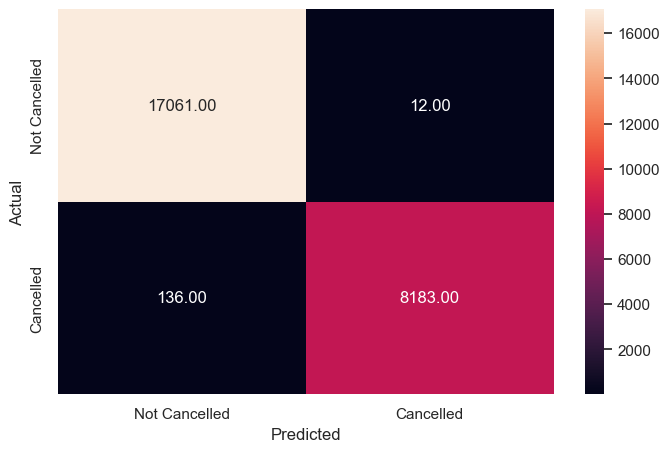

```python
# Remove _________ and complete the code

y_pred_train_rf = rf_estimator.predict(X_train)

metrics_score(y_train, y_pred_train_rf)
```

**Write your answers here:**_****

- For all the metrics in the training dataset, the Random Forest gives a 99% score.

```
              precision    recall  f1-score   support

           0       0.91      0.95      0.93      7317
           1       0.89      0.80      0.84      3566

    accuracy                           0.90     10883
   macro avg       0.90      0.87      0.88     10883
weighted avg       0.90      0.90      0.90     10883
```

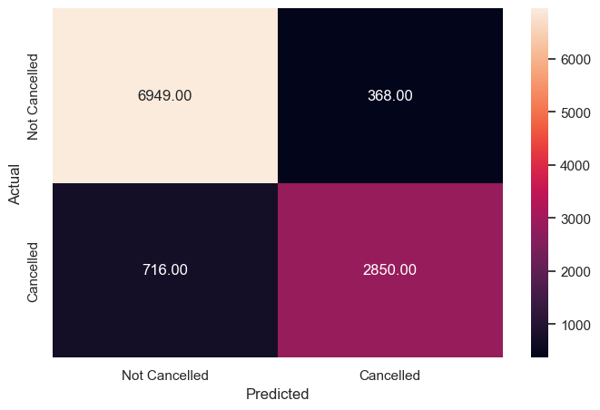

```python
# Remove _________ and complete the code

y_pred_test_rf = rf_estimator.predict(X_test)

metrics_score(y_test, y_pred_test_rf)
```

**Write your answers here:**_****

- The Random Forest classifier **seems to be overfitting the training data**. The accuracy (f1-score) on the training data is 0.99 (almost 1), while the accuracy (f1-score) on the test data is only ~ 0.90.
- Precision is high for the test data as well.

#### **Question 7.3: What are some important features based on the Random Forest? (1 Mark)**

Let's check the feature importance of the Random Forest

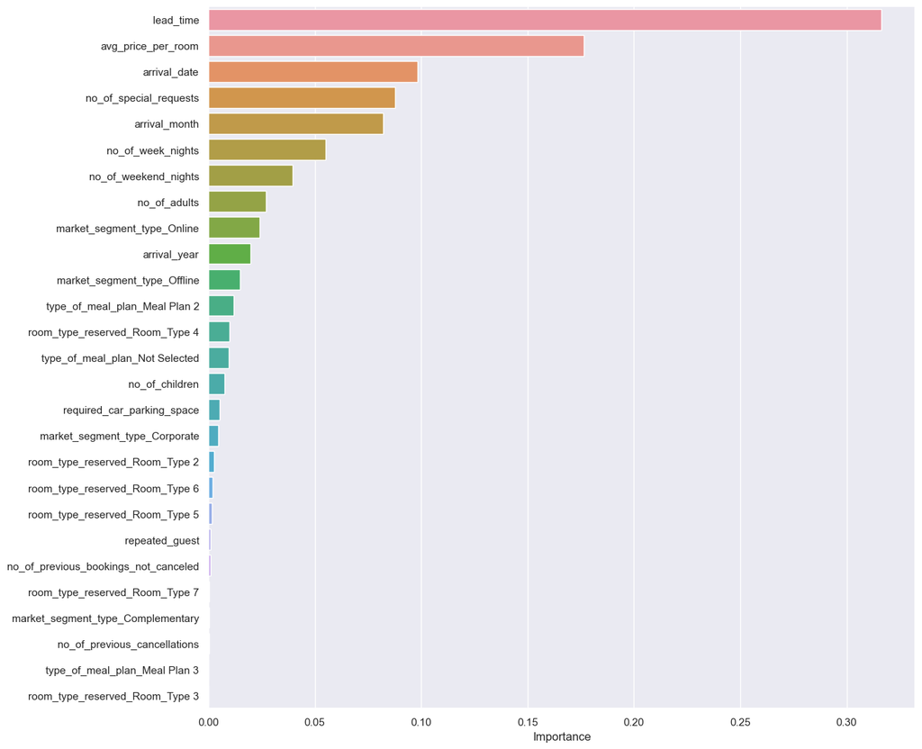

```python
# Remove _________ and complete the code

importances = rf_estimator.feature_importances_

columns = X.columns

importance_df = pd.DataFrame(importances, index = columns, columns = ['Importance']).sort_values(by = 'Importance', ascending = False)

plt.figure(figsize = (13, 13))

sns.barplot(x = "Importance", y = importance_df.index, data = importance_df )
```

**Write your answers here:**_**** The most important features for the Random Forest model are the following:

- lead_time
- avg_price_per_room
- arrival_date
- no_of_special_requests
- arrival_month

### **Question 8: Conclude ANY FOUR key takeaways for business recommendations (4 Marks)**

**Write your answers here:**_****

I have tried multiple models and able to identify key factors that affect the booking_status (cancel or not cancel) of customers booking hotel rooms:

- lead_time
- avg_price_per_room
- no_of_special_requests

These 3 factors are similar between the Decision Trees and Random Forest Models.

The tuned decision tree with F1-score accuracy of 85% and 84% for training and test dataset, respectively, reveals to be the best model to fit our key objective which is the following: "The hotel would want the `F1 Score` to be maximized, the greater the F1 score, the higher the chances of minimizing False Negatives and False Positives." This model can be used to predict whether a certain booking will get cancelled or not.

Here are 4 key business recommendations based on the findings of this project:

1. I can see that lead_time is the most important factor to deciding whether a customer will cancel the booking or not. The business could follow-up or confirm early with these customers when they make the bookings whether they would want to keep the bookings. A regular follow-up nearer the actual booking date is recommended.
2. It is found that repeat customers has a lower chance of cancelling. Keep these customers happy and satisfied with the whole booking experience and stay to ensure reduction of booking cancellations.
3. With relation to the 2nd recommendation, I'd recommend to include better promotions in the future for customer who booked and didn't cancel since these will be the repeat customers for the business. Build a better database of new potential customers.
4. Promote the idea of customers' ability to customize their booking with special requests. This will make their booking experience personalized and stand out compared to competitors.